# Simple Regression

Mother Height as a Predictor of Dauther Height

```r
library(psych)
library(arm)
library(car)
```

```r
heights <- read.csv("data/heights.csv", header = TRUE)
heights$X <- NULL
```

```r
# data(Galton, package = "mosaicData")
#
# heights <- Galton[Galton$sex == "F", c(3,5)]
# names(heights) <- c("mother_height", "daughter_height")
```

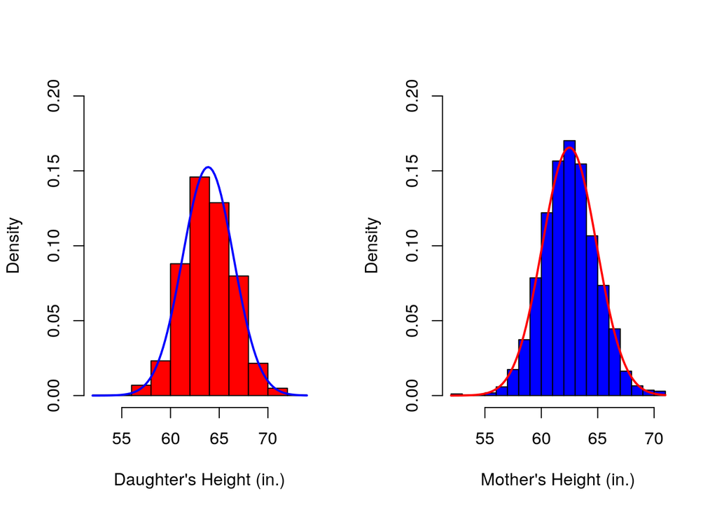

```r
par(mfrow = c(1,2)) # Make two plots per row
hist(heights$daughter_height, col = "red", probability = TRUE,
     ylim = c(0, .2), main = NULL, xlab = "Daughter's Height (in.)")
curve(dnorm(x, mean = mean(heights$daughter_height),
            sd = sd(heights$daughter_height)), add = TRUE,
      lwd = 2, col = "blue")
hist(heights$mother_height, col = "blue", probability = TRUE,
     ylim = c(0, .2), main = NULL, xlab = "Mother's Height (in.)")
curve(dnorm(x, mean = mean(heights$mother_height),
            sd = sd(heights$mother_height)),
            lwd = 2, col = "red", add = TRUE)
```

```r
par(mfrow = c(1,1)) # Go back to one plot per row
```

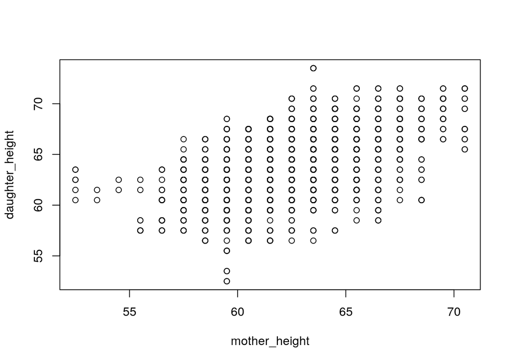

```r
plot(daughter_height ~ mother_height, heights)
```

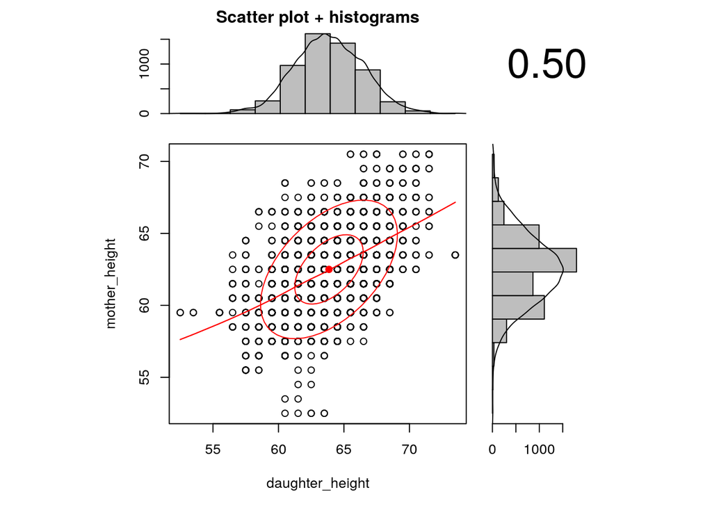

```r
scatterHist(heights)
```

```r
describe(heights, fast = TRUE)
```

```
                vars    n  mean   sd  min  max range   se
daughter_height    1 5524 63.86 2.62 52.5 73.5    21 0.04
mother_height      2 5524 62.50 2.41 52.5 70.5    18 0.03
```

```r
mod <- lm(daughter_height ~ mother_height, heights)
display(mod)
```

```
lm(formula = daughter_height ~ mother_height, data = heights)
              coef.est coef.se
(Intercept)   29.80     0.79
mother_height  0.54     0.01
---
n = 5524, k = 2
residual sd = 2.26, R-Squared = 0.25
```

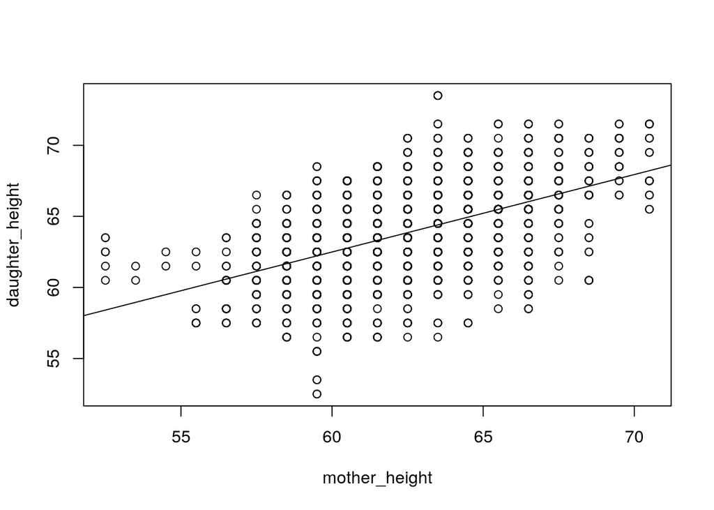

```r
plot(daughter_height ~ mother_height, heights)
abline(coef(mod))
```

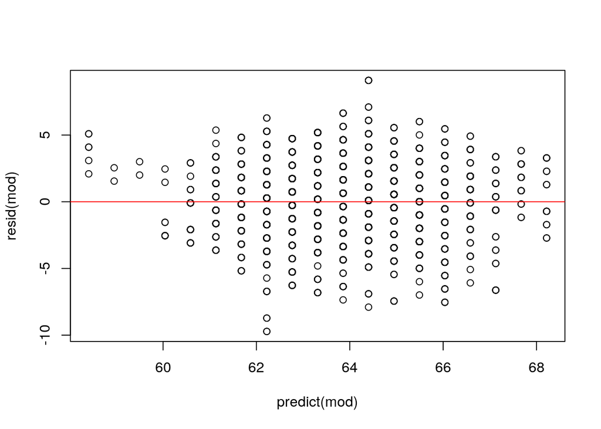

```r
plot(resid(mod) ~ predict(mod))
abline(h = 0, col = "red")
```

```r
coef(mod)
```

```
  (Intercept) mother_height
   29.7984062     0.5449368
```

For example, suppose we knew the average height of adult women in the United States is 64 inches, with a variance of 9 inches. As we will see below, the standard deviation is the square root of the variance, so the standard deviation for the height of adult women is $\sqrt{9} = 3$.

To illustrate the calculations below, we will randomly sample from the above described population, with the assumption that the height of women is normally distributed, which is a reasonable assumption. To help build our intuitions about these conceptual formulas, we will keep the sample small for now.

Let’s randomly sample 10 women from our population. To do this in R we need three values the sample size (n), the mean, and the standard deviation (sd). Then we can use the `rnorm()` function to create a vector of heights as:

```r
set.seed(1234)
height_women <- rnorm(n = 10, mean = 64, sd = 3)
```

I used `set.seed(1234)` to make this example reproducible. See `?set.seed` for more information.

If, for the vector $X$ we define another vector of deviation scores, $x$, as the difference between each value in $X$ and the mean of $X$, $\bar{X}$ as $x = X - \bar{X}$, then:

$$s_x^2 = \frac{\Sigma{(X - \bar{X})^2}}{N - 1} = \frac{x^2}{N- 1} \tag{2.1}$$
Let’s use R to calculate the variance of our `height_women` variable

```r
X <- height_women
N <- length(X)
```

First, I created a variable `X` which is just a copy of `height_women`, then I created a scalar `N` which is the number of women in our sample, which is 10.

We will use the deviation score to calculate the variance, so I create it here:

```r
# Calculate deviation scores.
x <- X - mean(X)
```

Finally, we calculate the variance and assign it to the symbol `sx2`

```r
# Calculate variance using deviation scores with equation (2.1)
sx2 <- sum(x^2)/(N - 1)

# Print variance
sx2
```

```
[1] 8.924335
```

The sample variance 8.9 is very close to the population variance of women’s height which we said was 9. We can think of the variance as the average squared deviation of the sample scores from their mean.

We did these “hand” calculations to demonstrate the concepts underlying the variance. We can calculate it much easier with the `var()` function:

```r
var(X)
```

```
[1] 8.924335
```

The standard deviation is the square root of the variance, so we can calculate it is various ways as follows.

```r
sx <- sqrt((sum(x^2))/(N-1)) # by 'hand'
sx
```

```
[1] 2.987363
```

```r
sd(X) # built-in R function
```

```
[1] 2.987363
```

### Covariance

The formula for covariance is similar to that of the variance.

$$s_{xy} = \frac{\Sigma{(X - \bar{X})(Y - \bar{Y})}}{N - 1} = \frac{\Sigma{xy}}{N - 1} \tag{2.3}$$